# Unsupervised_Learning_Project_Samir_Karandikar_R1

## 2. Insight from the Graphs

```
Properly comment on the codes, provide explanations of the steps taken in the notebook and conclude your insights from the graphs. (5 marks)
```

```python
#Total Visits to Bank appears to be the most important feature that forms three distinct clusters. Customers
# with high visits to bank have lower online visits.
#Average Credit Limit appears to be an important feature. There is some correlation with Total Credit Cards; higher
# the average credit limit, the individual has more credit cards, makes less visits to bank, higher online visits
# makes less calls. We could potentially look for cluster of customers with higher, average and lower credit limit.
# Total credit cards and Total visits online seem to form two distinct clusters with people with >5 online visits
# and these customers tend to have more than 7 credit cards.
# Customers making more (5-10)phone calls appear to have lower average credit limit.
```

## 3. K-Means Clustering

Execute K-means clustering use elbow plot and analyse clusters using boxplot (10 marks)

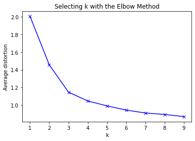

```python
#Finding optimal no. of clusters
from scipy.spatial.distance import cdist
clusters=range(1,10)
meanDistortions=[]

for k in clusters:
    model=KMeans(n_clusters=k)
    model.fit(Data_scaled)
    prediction=model.predict(Data_scaled)
    meanDistortions.append(sum(np.min(cdist(Data_scaled, model.cluster_centers_, 'euclidean'), axis=1)) / Data_scaled.shape[0])


plt.plot(clusters, meanDistortions, 'bx-')
plt.xlabel('k')
plt.ylabel('Average distortion')
plt.title('Selecting k with the Elbow Method')
```

```python
# Let us first start with K = 2 where we see an elbow in the graph above
first_model=KMeans(2)
first_model.fit(Data_scaled)
prediction=first_model.predict(Data_scaled)
```

```python
#Append the prediction
Data_df["Group"] = prediction
Data_df_features["Group"] = prediction
Data_scaled["Group"] = prediction
print("Groups Assigned: \n")
Data_df_features.head(10)
```

```
Groups Assigned:
```

|  | Avg_Credit_Limit | Total_Credit_Cards | Total_visits_bank | Total_visits_online | Total_calls_made | Group |
| --- | --- | --- | --- | --- | --- | --- |
| 0 | 100000 | 2 | 1 | 1 | 0 | 0 |
| 1 | 50000 | 3 | 0 | 10 | 9 | 1 |
| 2 | 50000 | 7 | 1 | 3 | 4 | 0 |
| 3 | 30000 | 5 | 1 | 1 | 4 | 0 |
| 4 | 100000 | 6 | 0 | 12 | 3 | 0 |
| 5 | 20000 | 3 | 0 | 1 | 8 | 1 |
| 6 | 100000 | 5 | 0 | 11 | 2 | 0 |
| 7 | 15000 | 3 | 0 | 1 | 1 | 1 |
| 8 | 5000 | 2 | 0 | 2 | 2 | 1 |
| 9 | 3000 | 4 | 0 | 1 | 7 | 1 |

### Let us analyze the clusters using Box plot

```python
DataClust = Data_df_features.groupby(['Group'])
DataClust.mean()
```

| Group | Avg_Credit_Limit | Total_Credit_Cards | Total_visits_bank | Total_visits_online | Total_calls_made |
| --- | --- | --- | --- | --- | --- |
| 0 | 46082.568807 | 5.885321 | 3.158257 | 2.119266 | 1.894495 |
| 1 | 12174.107143 | 2.410714 | 0.933036 | 3.553571 | 6.870536 |

```
array([[<matplotlib.axes._subplots.AxesSubplot object at 0x000002116D917550>,
      dtype=object)
```

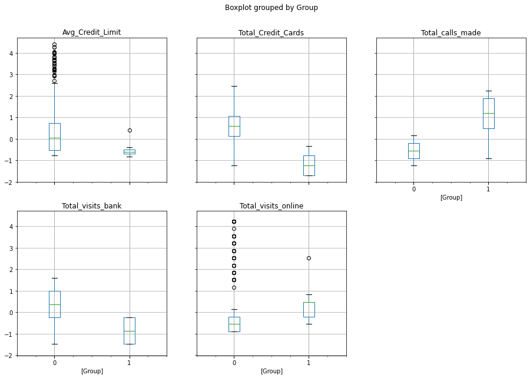

```python
Data_scaled.boxplot(by='Group', layout = (2,3),figsize=(15,10))
```

### We will try with K=3 which is the next elbow in the curve shown above.

```python
# Let us try next with K = 3
second_model=KMeans(3)
second_model.fit(Data_scaled)
prediction=second_model.predict(Data_scaled)

#Append the prediction to the data frames
Data_df["Group"] = prediction
Data_scaled["Group"] = prediction
Data_df_features["Group"] = prediction
print("Groups Assigned : \n")
Data_df.head()
```

```
Groups Assigned :
```

|  | Sl_No | Customer Key | Avg_Credit_Limit | Total_Credit_Cards | Total_visits_bank | Total_visits_online | Total_calls_made | Group |
| --- | --- | --- | --- | --- | --- | --- | --- | --- |
| 0 | 1 | 87073 | 100000 | 2 | 1 | 1 | 0 | 0 |
| 1 | 2 | 38414 | 50000 | 3 | 0 | 10 | 9 | 1 |
| 2 | 3 | 17341 | 50000 | 7 | 1 | 3 | 4 | 0 |
| 3 | 4 | 40496 | 30000 | 5 | 1 | 1 | 4 | 0 |
| 4 | 5 | 47437 | 100000 | 6 | 0 | 12 | 3 | 2 |

```python
DataClust = Data_df_features.groupby(['Group'])
DataClust.mean()
```

| Group | Avg_Credit_Limit | Total_Credit_Cards | Total_visits_bank | Total_visits_online | Total_calls_made |
| --- | --- | --- | --- | --- | --- |
| 0 | 33782.383420 | 5.515544 | 3.489637 | 0.981865 | 2.000000 |
| 1 | 12174.107143 | 2.410714 | 0.933036 | 3.553571 | 6.870536 |
| 2 | 141040.000000 | 8.740000 | 0.600000 | 10.900000 | 1.080000 |

```
array([[<matplotlib.axes._subplots.AxesSubplot object at 0x000002116E67F7F0>,
      dtype=object)
```

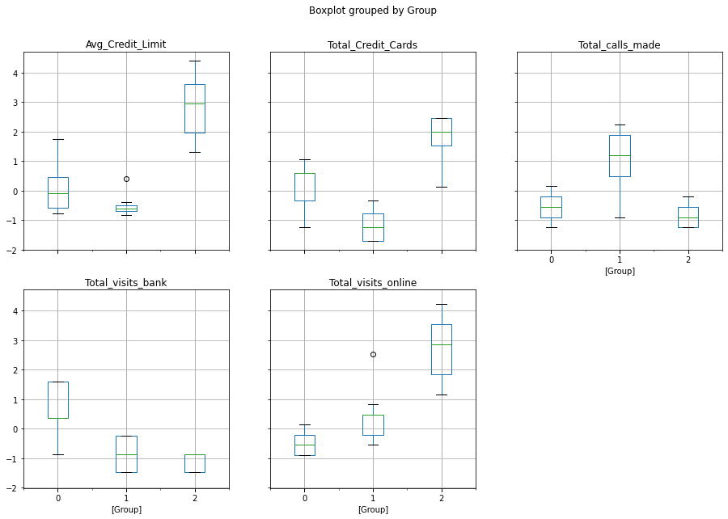

```python
Data_scaled.boxplot(by='Group', layout = (2,3),figsize=(15,10))
```

## We appear to be getting more distinct clusters with K = 3

- Group 2 appears to be made of high average credit limit, highest no. of credit cards, lower total calls and visits to the bank, and highest online visits to the bank.
- Group 0 appears to be made of average credit limit being average of the total, average total credit cards, lower calls made, highest no. of visits to the bank and lowest no. of visits online.
- Group 1 appears to be made of low average credit limit, lowest no. of credit cards, high total calls made to the bank, lower total visits to bank and average visits on-line.

## 4. Hierarchical Clustering -

```
Execute hierarchical clustering (with different linkages) with the help of dendrogram and cophenetic coeff. Analyse clusters formed using boxplot (15 marks)
```

```python
Data_df_features.drop(['Group'], axis = 1, inplace = True)
Data_df_features.head()
```

|  | Avg_Credit_Limit | Total_Credit_Cards | Total_visits_bank | Total_visits_online | Total_calls_made |
| --- | --- | --- | --- | --- | --- |
| 0 | 100000 | 2 | 1 | 1 | 0 |
| 1 | 50000 | 3 | 0 | 10 | 9 |
| 2 | 50000 | 7 | 1 | 3 | 4 |
| 3 | 30000 | 5 | 1 | 1 | 4 |
| 4 | 100000 | 6 | 0 | 12 | 3 |

```python
from sklearn.preprocessing import StandardScaler
import numpy as np
sc = StandardScaler()
X_std = pd.DataFrame(sc.fit_transform(Data_df_features),columns=Data_df_features.columns)
```

```python
X_std.head()
```

|  | Avg_Credit_Limit | Total_Credit_Cards | Total_visits_bank | Total_visits_online | Total_calls_made |
| --- | --- | --- | --- | --- | --- |
| 0 | 1.740187 | -1.249225 | -0.860451 | -0.547490 | -1.251537 |
| 1 | 0.410293 | -0.787585 | -1.473731 | 2.520519 | 1.891859 |
| 2 | 0.410293 | 1.058973 | -0.860451 | 0.134290 | 0.145528 |
| 3 | -0.121665 | 0.135694 | -0.860451 | -0.547490 | 0.145528 |
| 4 | 1.740187 | 0.597334 | -1.473731 | 3.202298 | -0.203739 |